# Exploratory Analysis

## Student Alcohol Consumption

### Authors

Duyen T Nguyen, Mor Vered, Nishant Shah, Kim Tran

### Date

Winter 2023

### Abstract

The main question we have with this data set is how popular is underage alcohol consumption? Underage substance usage is a significant health concern globally, and it is crucial to understand the root of the problem, such as what leads minors to consume alcohol, to create effective prevention. For this purpose, we want to analyze a data set containing the age of students who consume alcohol, their reasonings for doing so, as well as the various characteristics of minors that consume alcohol.

### Keywords

Alcohol Consumption, Underage Substance Usage, Behavior, Health, Student

### Introduction

In this project, we want to analyze the age of student alcohol consumption and their environment to see if there is any significant correlations that may lead certain minor to be more likely to consume alcohol. Understand this could help us in providing edaquate resources to specific groups of students to help combat underage alcohol consumption. The main questions we want to answer:

1. Which age group is the most common among this dataset? - To answer this question, we can group the provided data into specific age groups of interest (i.e 15-17, 18 - 22, etc.) to see the proportion of underage drinking among this group of participant.
2. What are some correlations between student underage drinking and their environment? - This question will require us to analyze columns of this dataset, which include family size, parental education and career status, sex, quality of family relationship, etc. Are there any correlations between these and student that drink? What is the most common reason/factor among each age group? A gaze into this could help us with understanding why certain youth choose to drink, and the kind of social, mental, and physical factor that may lead to drinking.
3. How does alcohol consumption affect students’ academic performance? - One of the biggest concern about underage alcohol consumption is the effect it may have on the brains that have yet to fully develop. Does underage alcohol consumption affect these students’ academic ability? Which group take the most toll from this? (It is also important to keep in mind that the students’ environment may also be a factor to their academic performance).

### Related Work

There are many health and safety risks associated with underage alcohol consumption that can negatively impact mental and physical well-being. We can gain a deeper understanding of the factors that drive underage drinking and its effects on students’ lives by analyzing the dataset we chose. For example, in the article by Cleveland Clinic, it was indicated that emotional and physical changes, peer pressure, stress, transitions, and possibly more made youth in the U.S. partake in underage drinking. Using the sources as a guide and using our dataset to analyze, we can infer the possible issues of underage drinking in Portugal and find out why so many minors drink. As many as two minors per week have been caught for underage drinking in Portugal, where the legal age for alcohol was recently changed to 18 The Portugal News. The article claims that ever since the law was changed in Portugal that there have been a lot more cases of underage drinking caught by the police. However it doesn’t state why minors are drinking or any other information about it. Another article from the Center for Disease Control states that “among high school students, 29% have drank alcohol in the past 30 days” CDC. They state that even though under age high school drinking rates have been generally decreasing over the past few decades, rates are still high. The results in our sources suggest there are social, economic, and political influence in underage alcohol consumption in the U.S. and Portugal.

References

Centers for Disease Control and Prevention. (2022, October 26). Underage drinking. Centers for Disease Control and Prevention. Retrieved February 3, 2023, from https://www.cdc.gov/alcohol/fact-sheets/underage-drinking.htm Health and safety still tackling underage drinking one year on from legal age hike. The Portugal News. (2016, July 7). Retrieved February 3, 2023, from https://www.theportugalnews.com/news/health-and-safety-still-tackling-underage-drinking-one-year-on-from-legal-age-hike/38786 Underage drinking: Alcohol poisoning, binge drinking, drinking age. Cleveland Clinic. (2021, March 28). Retrieved February 3, 2023, from https://my.clevelandclinic.org/health/articles/17541-alcohol-underage-drinking

### The Dataset

The data set being used is titled “Student Alcohol Consumption”, and this was found on Kaggle. The owner of this dataset goes by the name of UCI Machine Learning. The data reflects student alcohol use which was collected through a survey of students studying Portuguese and mathematics in primarily two secondary schools, Gabriel Peirera and Mousinho da Silveira, both located in Portugal. The data consists of information about students with respect to gender, age, and social culture. There is a separate dataset for each course, and there are several(382 specified in the data) students that belong to both sets. Both datasets have the same columns, a total of 33 - school, sex, age, address, famsize, Pstatus(parents apart or together), Medu(mother’s education), Fedu(father’s education), Mjob(Mother’s job), Fjob(Father’s job), reason(to choose this school), guardian, traveltime, studytime, failures, schoolsup (extra educational support), famup(family educational support), paid(extra paid classes), activities, nursery, higher(want to take higher education), internet, romantic(in a romantic relationship), famrel(quality of family relationships), freetime, goout(go out with friends), Dalc(workday alcohol consumption), Walc(weekend alcohol consumption), health, absences, G1(first period grade), G2(second period grade), G3(final grade). One of the main ethical considerations when working with this data is the accuracy of the responses, as students may underreport their alcohol consumption due to the legal age for drinking and potential societal repercussions. Additionally, the sample size is limited to only two schools in Portugal, which may not accurately represent the drinking patterns of students in other regions or countries. Furthermore, the dataset only includes information on students’ alcohol consumption and does not address other factors, such as mental health or peer pressure, that may impact alcohol use.

### Implications

One of the major possible implications that comes to mind is how this data can be used to design more effective and efficient alcohol prevention campaigns that target students. It can be used to understand the cultural, social, educational factors that influence students’ drinking behaviors, and create policies that target these factors. It can be used to develop policies aimed at reducing alcohol consumption and get a better idea of different factors that impact student alcohol consumption and craft policies to address them. It can also highlight the impact of parental education, family relationships and jobs on students’ alcohol consumption. For technologists, the findings from this dataset could also lead to the development of new tools and applications for tracking and monitoring alcohol consumption, which could be useful for parents, schools, and policymakers. These tools could be designed to help students and parents better understand the risks associated with alcohol consumption and provide early interventions to prevent harmful drinking behaviors.

### Limitations & Challenges

Some challenges and limitations that may come up with our project is that our dataset does not originate from the United States, and considering this, we might have a harder time understanding how the trends we find within the dataset appear in the US among students. It is very hard to find any data for student alcohol consumption within America, and this could be because the legal age for drinking alcohol is so high compared to many other countries. Also, getting such data in the US is a privacy concern for the people involved, making it not accessible to a regular person. Thus, even though many students may participate in underage drinking, no one will talk about it in the US because they don’t want to get caught and have legal implications. We also have to consider that because we are using a dataset about something people do that is illegal, many people may lie and say they have never done it, when that might not be the case. This is something that we must take into consideration when looking at overall statistics and trends in the data.

### Summary Information

Through our analysis of this dataset, we have found a few interesting trends which help us understand how student alcohol consumption affects students. Out of the almost 200 students in this data set who rated that they drink a 2 on a scale of 1-5 (low to high alcohol consumption) during the work week, 182 are not in paid classes. Compared to 16, is a massive difference. The value 529, 120 calculate the number of student who described their weekend drinking habit as moderate (3 out of 5), which can be a nice middle ground. The 2.24270072992701, 2.48514851485149 show the average of rating of weekedn alcohol consumption of student who described their family relationship quality as average.

### Table

```
## # A tibble: 50 × 8
## # Groups:   sex, Parental Status [4]
##    sex   age   `Parental Status` Family Relati…¹ Going…² Weekd…³ Weeke…⁴ Healt…⁵
##    <chr> <chr> <chr>             <chr>           <chr>   <chr>   <chr>   <chr>
##  1 F     17    A                 4               4       1       1       1
##  2 F     15    A                 5               2       1       1       5
##  3 F     16    A                 2               5       1       4       3
##  4 F     17    T                 5               3       1       1       3
##  5 F     15    T                 4               2       2       3       3
##  6 F     15    T                 3               2       1       1       5
##  7 F     16    T                 4               2       1       2       5
##  8 F     15    T                 3               3       1       2       2
##  9 F     15    T                 5               2       1       1       4
## 10 F     16    T                 4               4       1       2       2
## # … with 40 more rows, and abbreviated variable names ¹`Family Relationship`,
## #   ²`Going Out With Friends`, ³`Weekday Alc Consumption`,
## #   ⁴`Weekend Alc Consumption`, ⁵`Health Condition`
```

Legend: 1. sex - student’s sex (binary: ‘F’ - female or ‘M’ - male) 2. age - student’s age (numeric: from 15 to 22) 3. Parental Status - parent’s cohabitation status (binary: ‘T’ - living together or ‘A’ - apart) 4.Family Relationship - quality of family relationships (numeric: from 1 - very bad to 5 - excellent) 5. Going Out with Friends - going out with friends (numeric: from 1 - very low to 5 - very high) 6. Weekday Alc Consumption - weekday alcohol consumption (numeric: from 1 - very low to 5 - very high) 7. Weekend Alc Consumption - weekend alcohol consumption (numeric: from 1 - very low to 5 - very high) 8. Health Condition - current health status (numeric: from 1 - very bad to 5 - very good)

The table provides a quick way to summarize the data, allowing us to compare the different variables and identify patterns or relationships between them. The reason for selecting a table with these specific columns is to gain better insights into the factors that might affect the alcohol consumption habits and overall health of underage students. For instance, we can use the table to examine the relationship between family relationship and alcohol consumption, or between going out with friends and alcohol consumption, and how these factors might impact students’ overall health. I feel that the columns I selected may have more significance or importance as it highlights critical issues that could be related to underage drinking. I wanted to keep the age under 18 to get the most extreme cases of underage drinking. After skimming through the table that was projected from the code, the table revealed some pretty interesting data. Looks like most of them had a pretty good relationship with their family and that might not have been the case for drinking. However, a lot of them seem to not go out often with friends, and maybe the drinking arised from loneliness. Also, it looks like a lot of them don’t have a great health condition which I guess is due to a lot of drinking. Interesting thing to note - looks like weekday and weekend alcohol consumptions are low, but the health data seems to contradict that. It would be fascinating to explore more of the dataset to see any changes in this trend outside the table.

### Chart 1

[figure not shown]

### Chart 2

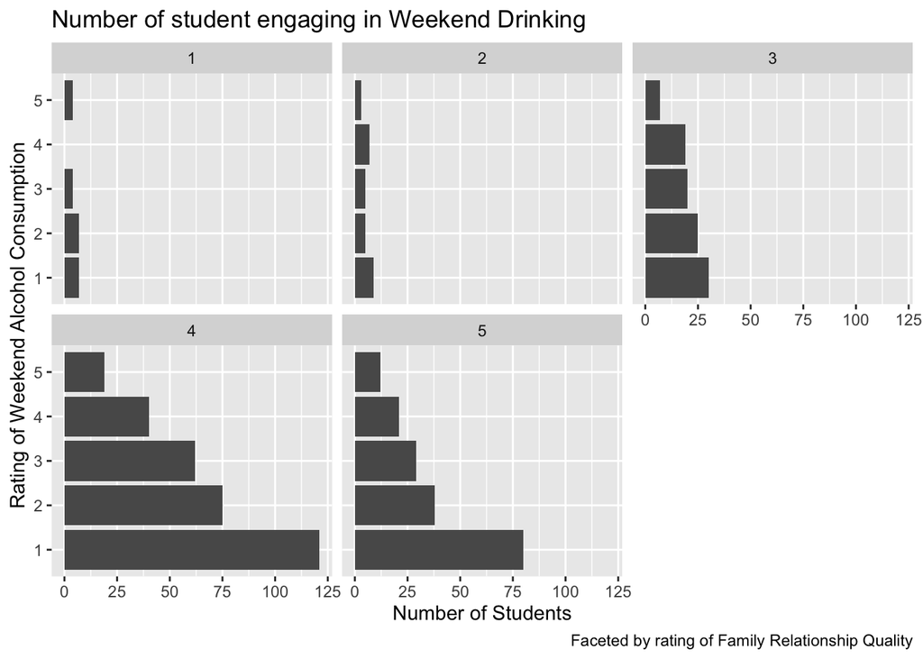

I choose this faceted chart to see if there is any relationship to the number of students drinking on weekend, as well as their severity, and their rating of their family quality. My hypothesis was that maybe if students were not having a great time at home, they will be more likely to go out and/or drink on the weekend.

### Chart 3

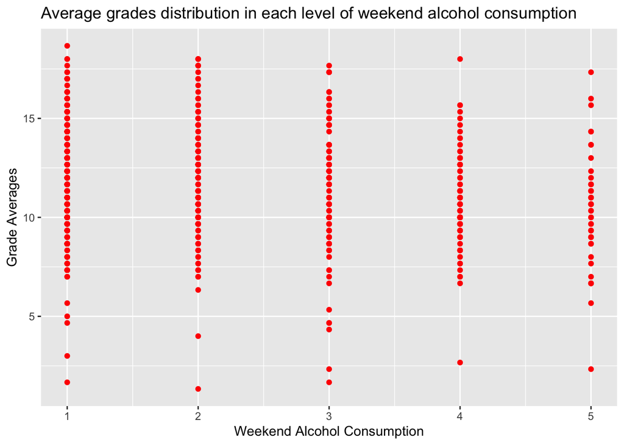

I choose this scatter plot chart to see if theres a correlation between the different levels of weekend alcohol consumption and the different average grades students get. My hypothesis was that if students who have high levels of weekend alcohol consumption then their grades on average will be lower.